[Home](https://jmyao17.github.io)

# Introduction to probability

[figure not shown]

## Probability

It is a measure of likeliness that an event will occur. The probability that event A occurs is denoted by P(A) or Pr(A).

Probability axioms:

- Non-negative:

$$ 0 \leq P(E)\leq 1\quad, \forall E \in \{events\} $$

- Unitarity: For entire sample space $\Omega$

$$ P(\Omega) = 1 $$

- additive law:

$$ P(A \cup B) = P(A) + P(B) - P(A \cap B) $$

## Independence

The probability of two independent events $E$ and $F$ (flip coins) happening is given by

$$ P(E, F) = P(E) * P(F) $$

## Dependence and conditional probability

Given that the event $F$ happens, the probability of the event $E$ happens reads

$$ P(E, F) = P(E|F) * P(F) \neq P(E) * P(F) $$

where the $P(E|Y)$ is the probability of $E$, *"conditional on $F$"* .

## Bayes

Based on the fact $$ P(E, F) = P(F, E), $$ one finds the relation $$ P(E|F) * P(F) = P(F|E) * P(E) $$ which can be rewritten as

\begin{align} P(E|F) &= \dfrac{P(F|E) * P(E)}{P(F)} \nonumber\\ &= \dfrac{P(F|E) * P(E)}{P(F|E)*P(E) + P(F|\bar E)*P(\bar E)}, \end{align}

with $P(\bar E) = 1 - P(E)$.

## Probability density (mass) function (pdf)

The probability of the random variable falling within a particular range of values. This probability is given by the integral of this variable’s pdf over that range.

The standard **normal distribution** has probability density: $$ f(x) = \frac{1}{\sqrt{2\pi}\sigma}\; e^{-(x-\mu)^2/(2\sigma^2)}. $$

The $f(x)$ should satisfy:

$$ f(x)\ge0,\quad \int f(x) dx =1. $$

$$ P(a\leq x \leq b) = \int^b_a f(x)dx $$

## Cumulative density function (cdf)

The probability of the $X$ taking a value less than or equal to $x$

$$ F_X(x) = P(X\leq x)=\int^x_{-\infty} f_X(t)dt $$

## Mean, variance and standard deviation

If a random variable $x$ is given and its distribution admits a probability density function $f(x)$, then the expected (mean) value of $x$ (if the expected value exists) can be calculated as $$ \operatorname{E}[x] = \int_{-\infty}^\infty x\,f(x)\,dx. $$

- $E[c*x]$ = $c*E[x]$
- $E[x+b]$ = $E[x]+b$

The **variance** of the random variable $X$ is defined as $$ V[x] = E[(x-E[x])^2] = E[x^2]-E^2[x] $$

- $V[c]$=$0$
- $V[x$+$c]$=$V[x]$
- $V[c$*$x]$=$c^2V[x]$

where $c$ is a constant.

The **standard deviation** is defined as $$ D[x] = \sqrt{V[x]}. $$

## The skewness and kurtosis

- skewness: $E[(x-E[x])^3]/D^3[x]$
- kurtosis: $E[(x-E[x])^4]/D^4[x]-3$, where $-3$ is introduced so that the kurtosis of the normal distribution is zero.

## Moments

- The $k$-th moments

$$ \mu_k = E[x^k] $$

- The $k$-th central moments: a moment of a probability distribution of a random variable about the random variable's mean $$ \nu_k = E[(x-E[x])^k] $$

## The moment-generating function

$$ M_x(t) = E[e^{tx}]=\sum_x e^{tx}f(x), $$ where $$ e^{tx} = 1 + tx + \dfrac{t^2x^2}{2!}+\cdots $$ one can prove that $\dfrac{d^{(k)}}{d^k t}M_x(t)\vert_{t=0}=\mu_k$, from which one finds

- mean $E[X]=\mu_1$
- variance $V[X]=E[X^2]-E^2[X]=\mu_2-\mu^2_1$

## The central limit theorem

The central limit theorem states that when an infinite number of successive random samples are taken from a population, the sampling distribution of the means of those samples will become approximately normally distributed with mean $\mu$ and standard deviation $\sigma/\sqrt{N}$ as the sample size (N) becomes larger, irrespective of the shape of the population distribution.

$$ z = \dfrac{\bar x-\mu}{\sigma/\sqrt{n}} \sim N(0,1) $$

```python
import matplotlib.pyplot as plt
from scipy.stats import norm
import numpy as np
import collections
```

## An example: Binomial distribution

1. **Binomial distribution**: the discrete probability distribution of the number of successes in a sequence of $n$ independent experiments, each asking a yes–no question with outcome of a random variable containing a single bit of information: success/yes/true/one (with probability $p$) or failure/no/false/zero (with probability $q = 1 − p$).
1. For $n=1$ (a single success/failure experiment) case, the **Binomial distribution** is simplified to be **Bernoulli distribution**. If $X$ is a random variable with this distribution, then:

$$ \Pr(X=1) = p = 1 - \Pr(X=0) = 1 - q. $$

- The *pdf* of this distribution over possible outcomes $X=k$, is

$$ f(k, p) = \begin{cases} p & \text{if }k=1, \\ q = 1-p & \text {if } k = 0. \end{cases} $$

- The mean $\mu_1=E[X]=p$ and the standard deviation $$ V[X] = E[X^2]-E^2[X] = E[X^2] - \mu^2 = \sum_{k=0,1} f(k, p)\cdot k^2 -p^2 = p - p^2 = p(1-p). $$
1. Considering a set of binomially distributed $n$ random variables $\{X_1, X_2,\cdot, X_n\}$, denoted as $X\sim B(n,p)$. Each variable $X_i$ has the $p$ probability of taking the value 1 and $q=1-p$ probability of taking the value 0.

Note: $\{X_1, X_2,\cdot, X_n\}$ are $n$ independent variables and thus

$\begin{align} E[X] = E[\sum_i X_i] = \sum_i E[X_i], \\ V [X] = V [\sum_i X_i] = \sum_i V[X_i]. \end{align}$

- The mean of the $n$ random variables is

\begin{eqnarray} \mu_1 = E[X] \equiv \dfrac{1}{n}\sum^n_i X_i = \sum^n_{k=0} k \cdot f(k, n, p) \end{eqnarray} where the probability of getting exactly $k$ successes ($X=1$) in n trials is given by the probability mass function $$ f(k, n, p) = C^k_n p^k (1-p)^{n-k}. \quad $$

$\begin{align} \mu &= \sum_{k=0}^n k f(k)=\sum_{k=0}^n k\binom nk p^k (1-p)^{n-k}\\ &= \sum_{k=0}^n k\frac{n(n-1)!}{(n-k)!k!}p\cdot p^{k-1} (1-p)^{(n-1)-(k-1)}\\ &= np\sum_{k=1}^n \frac{(n-1)!}{((n-1)-(k-1))!(k-1)!}p^{k-1} (1-p)^{(n-1)-(k-1)}\\ &= np\sum_{\ell=0}^{n-1} \binom{n-1}\ell p^\ell (1-p)^{(n-1)-\ell} && \text{with } \ell:=k-1\\ &= np(p+(1-p))^m \\ &=np \end{align}$

The above relation can be derived in a simpler way as $$ \mu = E[X] = E[X_1+X_2+\cdot+X_n]= \sum^n_{i=1}E[X_i]=np. $$

- The standard deviation of binomially distributed variables reads

\begin{align} V[X] \equiv E[X^2] - E^2[X] = \sum^n_{i=1} (E[X^2_i] -E^2[X_i]) &=\sum^n_{i=1} V[X_i] \nonumber\\ &= \sum^n_{i=1} p(1-p)\nonumber\\ &=np(1-p). \end{align}

The moment-generating function $M_x(t)$ of $B(n,p)$ can be obtained by using the binomial theorem,

$$ M_x(t) = \sum_x e^{tx}f(x) =\sum^n_{x=0} e^{tx} C^x_n p^x q^{n-x} =\sum^n_{x=0} C^x_n (pe^{t})^x q^{n-x} =(pe^t+q)^n. $$ The mean and variance are simply given by

- $E[X]=\mu_1=M^{(1)}(t)\vert_{t=0}=n(pe^t+q)^{n-1}p\vert_{t=0}=np$
- $V[X]=\mu_2-\mu^2_1=n(n-1)p^2+np -n^2p^2 = np-np^2 = np(1-p)=npq$,

where $$ \mu_2=M^{(2)}(t)\vert_{t=0}=n(n-1)p^2+np $$

```python
# =1 with probability p
# =0 with probability (1-p)
# use the np.random.random() to return random floats in the half-open interval [0.0, 1.0)
def bernoulli_trial(p):
    return 1 if np.random.random()<p else 0

# sum over the x values for each 100 times:
# binomial(n,p) returns the sum^100_i x_i, where x_i=1 or 0.
def binomial(n,p):
    return sum(bernoulli_trial(p) for _ in range(n)) # generate n numbers of data; use _ to ignore the index

def make_hist(p,n,num_points):
    # data collects the frequencies (/number_points) of occuring values obtained from binomial(n,p)
    data = [binomial(n,p) for _ in range(num_points)]
    histogram = collections.Counter(data)
    print(len(data))
    plt.bar([x-0.4 for x in histogram.keys()],
           [v/num_points for v in histogram.values()])

    z = np.linspace(norm.ppf(0.0001), norm.ppf(0.99999), 100) # Percent point function (inverse of cdf — percentiles).
    fz  = norm.pdf(z)
    mu  = n*p
    sig2 = n*p*(1.0-p)
    x   = np.array(np.sqrt(sig2)*z+mu)
    fx  = fz/np.sqrt(sig2)
    plt.plot(x, fx,'r-', lw=5, alpha=0.6, label='norm pdf')
```

```
10000
```

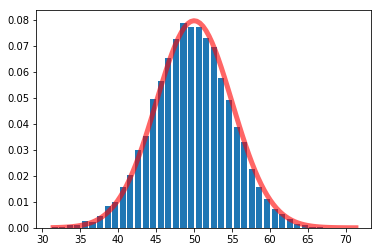

```python
make_hist(0.5,100,10000) # p=0.5, q=0.5, n=100
```

```python
def make_hist_abs(p,n,num_points):
    data = [binomial(n,p) for _ in range(num_points)] # num_points of data
    histogram = collections.Counter(data)
    print(len(data))
    plt.bar([x-0.4 for x in histogram.keys()],
           [v for v in histogram.values()])
```

```
10000
```

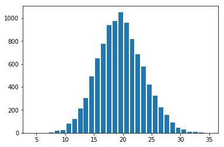

```python
make_hist_abs(0.2,100,10000)
```

```
Text(0.5,0,'x')
```

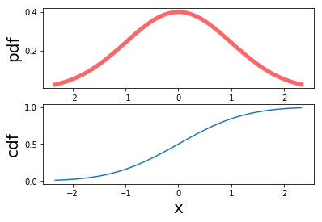

```python
fig,(ax1,ax2)= plt.subplots(2,1)
x = np.linspace(norm.ppf(0.01), norm.ppf(0.99), 100) # Percent point function (inverse of cdf — percentiles).
ax1.plot(x, norm.pdf(x),'r-', lw=5, alpha=0.6, label='norm pdf')
ax1.set_ylabel('pdf',size=20)
ax2.plot(x, norm.cdf(x))
ax2.set_ylabel('cdf',size=20)
ax2.set_xlabel('x',size=20)
```